# Analysing simulations

Gibran Hemani

```r
library(knitr)
knitr::opts_chunk$set(echo=TRUE, message=FALSE, warning=FALSE, dev="png", cache=TRUE)
```

Simulations run using [this model](https://www.draw.io/?state=%7B%22ids%22:%5B%221VqjTd4iH2de7sXI4PhUrxazBnYLduH_w%22%5D,%22action%22:%22open%22,%22userId%22:%22104793251732516248976%22%7D)

```r
library(tidyverse)
library(pROC)
load("../results/sim_summary.rdata")
```

There are three classes of simulation

- u1: Genetic variants influence a confounder (u1) of X and Y
- u2: Instruments for X have pleiotropic effects on Y that are mediated by some other trait called u2
- u3: Genetic instruments on X also directly influence a mediator (u3) between X and Y

## Setup data

For each simulation there are some invalid instruments. What is the range of invalidity:

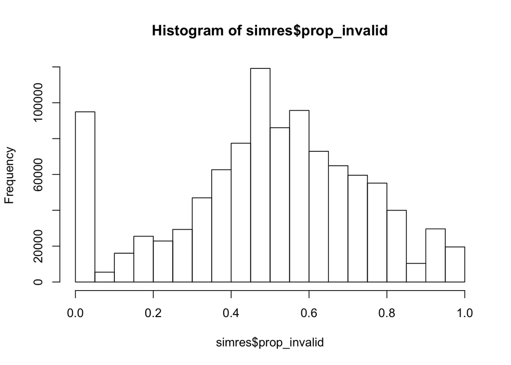

```r
simres$prop_invalid_bin <- cut(simres$prop_invalid, breaks=c(0, 0.2, 0.4, 0.6, 0.8, 1), ordered=TRUE)
hist(simres$prop_invalid)
```

```r
simres$prop_invalid_bin2 <- do.call(rbind, strsplit(as.character(simres$prop_invalid_bin), split=","))[,1] %>% gsub("\\(", "", .) %>% as.numeric
table(simres$prop_invalid_bin)
```

```
##
##   (0,0.2] (0.2,0.4] (0.4,0.6] (0.6,0.8]   (0.8,1]
##    112416    161778    378390    252504     99540
```

```r
table(simres$set)
```

```
##
##     U1     U2     U3
## 651408 287448  95340
```

## U1

The influence of invalid instruments on the performance of each method in terms of **bias**

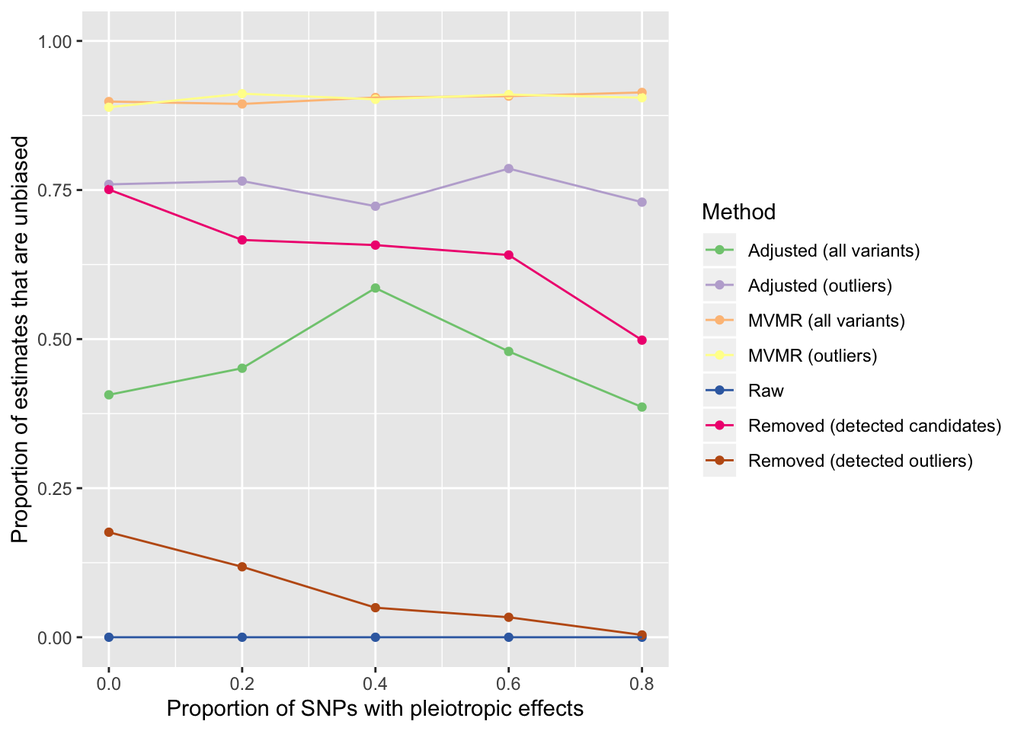

```r
simresu1 <- subset(simres, set == "U1")
sumu1 <- simresu1 %>%
    group_by(method, prop_invalid_bin2, set) %>%
    summarise(
        n=n(),
        psig=sum(pval < 1e-3, na.rm=TRUE) / n(),
        bias=sum(pdiff > 0.05, na.rm=TRUE) / n(),
        isq=mean(Isq)
    )

p1 <- sumu1 %>%
filter(!grepl("Hybrid", method)) %>%
ggplot(aes(y=bias, x=prop_invalid_bin2, group=as.factor(method)), colour=as.factor(method)) +
geom_point(aes(colour=as.factor(method))) +
geom_line(aes(colour=as.factor(method))) +
scale_colour_brewer(type="qual") +
labs(x="Proportion of SNPs with pleiotropic effects", y="Proportion of estimates that are unbiased", colour="Method", shape="Outlier detection", linetype="Outlier detection") +
ylim(c(0,1))
p1
```

Influence on power / false discovery rates. Calculate the AUROC for each method across the simulations

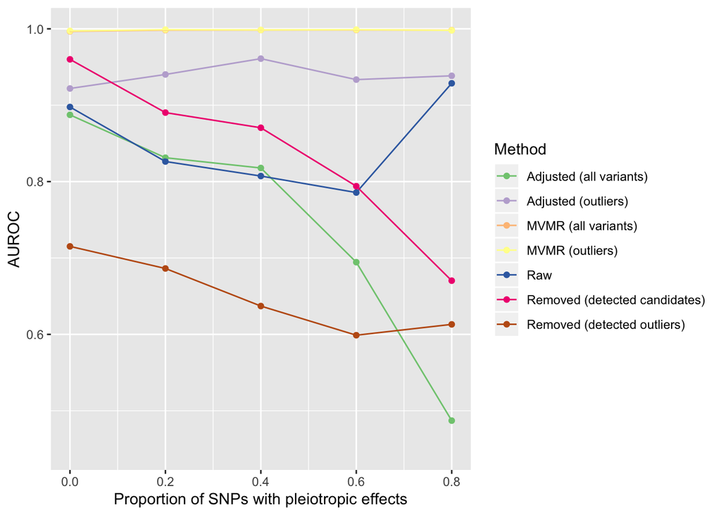

```r
sumu1b <- simresu1 %>%
    group_by(method, prop_invalid_bin2, set) %>%
    mutate(outcome=as.numeric(bxy != 0)) %>%
    summarise(
        n=n(),
        auc = roc(outcome, -log10(pval))$auc,
        psig=sum(pval < 1e-3, na.rm=TRUE) / n(),
        bias=sum(pdiff < 0.05, na.rm=TRUE) / n(),
        isq=mean(Isq)
    )

p2 <- sumu1b %>%
filter(!grepl("Hybrid", method)) %>%
ggplot(aes(y=auc, x=prop_invalid_bin2, group=as.factor(method)), colour=as.factor(method)) +
geom_point(aes(colour=as.factor(method))) +
geom_line(aes(colour=as.factor(method))) +
scale_colour_brewer(type="qual") +
labs(x="Proportion of SNPs with pleiotropic effects", y="AUROC", colour="Method", shape="Outlier detection", linetype="Outlier detection") +
ylim(c(0.45, 1))
p2
```

## U2

The influence of invalid instruments on the performance of each method in terms of **bias**

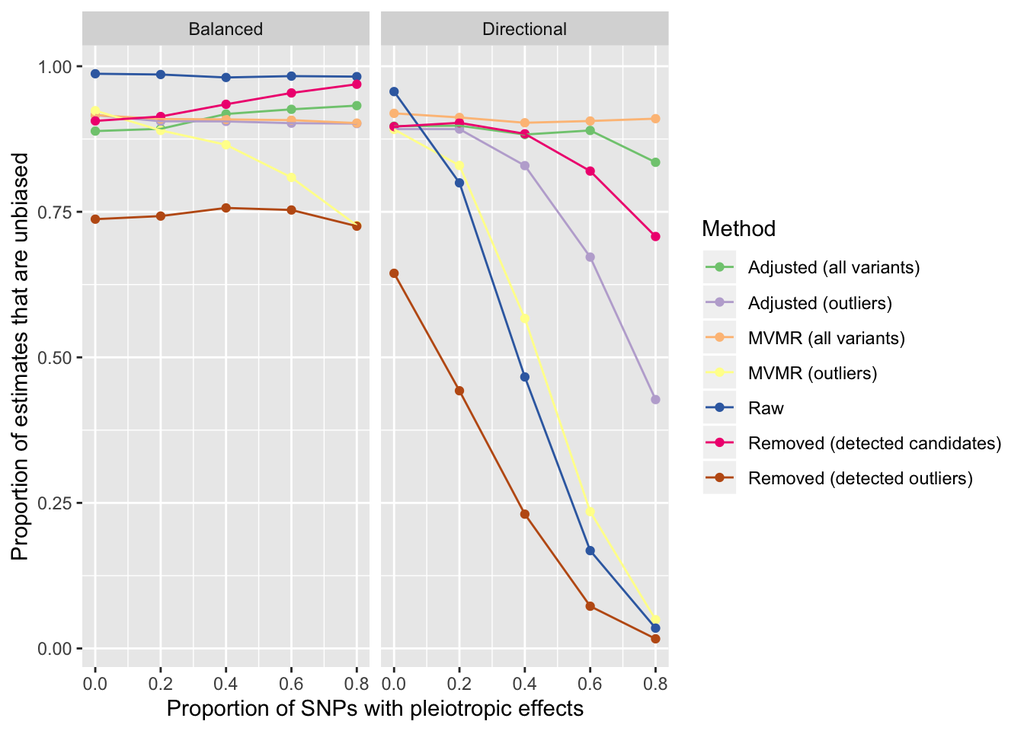

```r
simresu2 <- subset(simres, set == "U2")
simresu2$directional_bias2 <- simresu2$directional_bias
simresu2$directional_bias2[simresu2$directional_bias] <- "Directional"
simresu2$directional_bias2[!simresu2$directional_bias] <- "Balanced"
sumu2 <- simresu2 %>%
    group_by(method, prop_invalid_bin2, set, directional_bias2) %>%
    summarise(
        n=n(),
        psig=sum(pval < 1e-6, na.rm=TRUE) / n(),
        bias=sum(pdiff > 0.05, na.rm=TRUE) / n(),
        isq=mean(Isq)
    )

p3 <- sumu2 %>%
filter(!grepl("Hybrid", method), !is.na(prop_invalid_bin2)) %>%
ggplot(aes(y=bias, x=prop_invalid_bin2, group=as.factor(method)), colour=as.factor(method)) +
geom_point(aes(colour=as.factor(method))) +
geom_line(aes(colour=as.factor(method))) +
facet_grid(. ~ directional_bias2) +
scale_colour_brewer(type="qual") +
labs(x="Proportion of SNPs with pleiotropic effects", y="Proportion of estimates that are unbiased", colour="Method", shape="Outlier detection", linetype="Outlier detection")
p3
```

Influence on power / false discovery rates. Calculate the AUROC for each method across the simulations

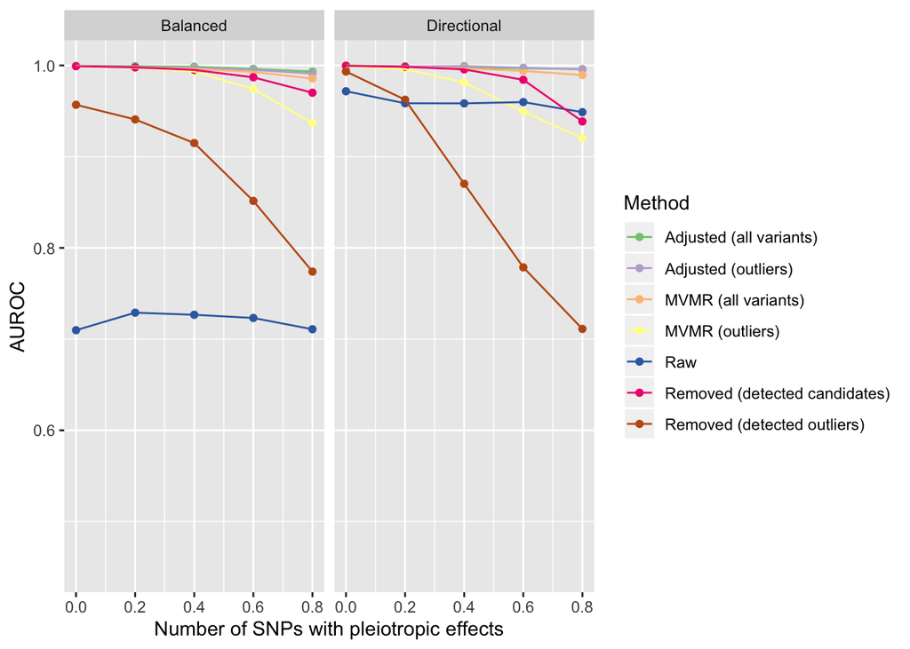

```r
sumu2b <- simresu2 %>%
    subset(!is.na(prop_invalid_bin2)) %>%
    group_by(method, prop_invalid_bin2, set, directional_bias2) %>%
    mutate(outcome=as.numeric(bxy != 0)) %>%
    summarise(
        n=n(),
        auc = roc(outcome, -log10(pval))$auc,
        bias=sum(pdiff < 0.05, na.rm=TRUE) / n(),
        isq=mean(Isq)
    )

p4 <- sumu2b %>%
filter(!grepl("Hybrid", method), !is.na(prop_invalid_bin2)) %>%
ggplot(aes(y=auc, x=prop_invalid_bin2, group=as.factor(method)), colour=as.factor(method)) +
geom_point(aes(colour=as.factor(method))) +
geom_line(aes(colour=as.factor(method))) +
facet_grid(. ~ directional_bias2) +
scale_colour_brewer(type="qual") +
labs(x="Number of SNPs with pleiotropic effects", y="AUROC", colour="Method", shape="Outlier detection", linetype="Outlier detection") +
ylim(c(0.45, 1))
p4
```

## U3

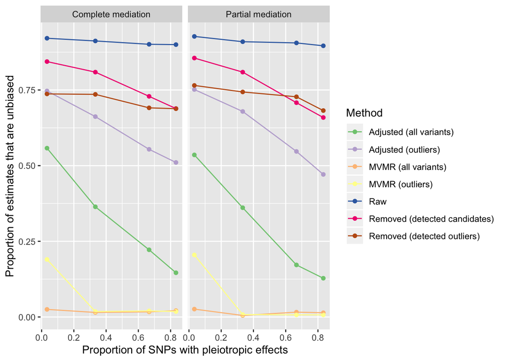

```r
simresu3 <- subset(simres, set == "U3")
simresu3$mediation <- "Partial mediation"
simresu3$mediation[simresu3$bxy == 0] <- "Complete mediation"
simresu3$bxy <- simresu3$bxy + simresu3$bxu3 * simresu3$bu3y
simresu3$diff <- simresu3$b - simresu3$bxy
simresu3$pdiff <- pt(abs(simresu3$diff)/simresu3$se, simresu3$nsnp, lower.tail=FALSE)

sumu3 <- simresu3 %>%
    group_by(method, ngxu3, ngx, set, mediation) %>%
    summarise(
        n=n(),
        psig=sum(pval < 0.05, na.rm=TRUE) / n(),
        bias=sum(pdiff > 0.05, na.rm=TRUE) / n(),
        isq=mean(Isq)
    )

inMap <- function(x, from, to) (x - min(x)) / max(x - min(x)) * (to - from) + from

sumu3$psig <- inMap(c(0,1,sumu3$psig), 0.5, 1)[-c(1,2)]

p5 <- sumu3 %>%
filter(!grepl("Hybrid", method), !is.na(ngxu3)) %>%
ggplot(aes(y=bias, x=ngxu3/ngx, group=as.factor(method)), colour=as.factor(method)) +
geom_point(aes(colour=as.factor(method))) +
geom_line(aes(colour=as.factor(method))) +
facet_grid(. ~ mediation) +
scale_colour_brewer(type="qual") +
labs(x="Proportion of SNPs with pleiotropic effects", y="Proportion of estimates that are unbiased", colour="Method", shape="Outlier detection", linetype="Outlier detection")
p5
```

Influence on power.

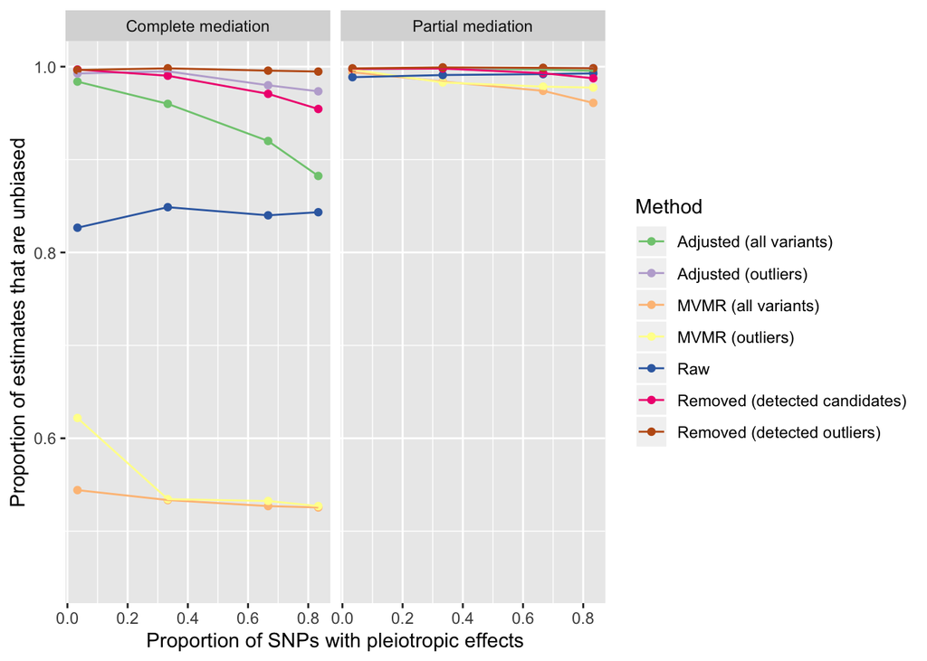

```r
p6 <- sumu3 %>%
filter(!grepl("Hybrid", method), !is.na(ngxu3)) %>%
ggplot(aes(y=psig, x=ngxu3/ngx, group=as.factor(method)), colour=as.factor(method)) +
geom_point(aes(colour=as.factor(method))) +
geom_line(aes(colour=as.factor(method))) +
facet_grid(. ~ mediation) +
scale_colour_brewer(type="qual") +
labs(x="Proportion of SNPs with pleiotropic effects", y="Proportion of estimates that are unbiased", colour="Method", shape="Outlier detection", linetype="Outlier detection") +
ylim(c(0.45, 1))
p6
```

## Summary

Overall, what proportion of times does each of the methods best perform?

```r
overall <- bind_rows(
    sumu1 %>% filter(!grepl("Hybrid", method)) %>%
    group_by(prop_invalid_bin2) %>%
    arrange(desc(bias)) %>%
    mutate(rank=1:n(), what="bias") %>%
    select(method, set, rank, what),

    sumu1b %>% filter(!grepl("Hybrid", method)) %>%
    group_by(prop_invalid_bin2) %>%
    arrange(desc(auc)) %>%
    mutate(rank=1:n(), what="auroc") %>%
    select(method, set, rank, what),

    sumu2 %>% filter(!grepl("Hybrid", method)) %>%
    group_by(prop_invalid_bin2, directional_bias2) %>%
    arrange(desc(bias)) %>%
    mutate(rank=1:n(), what="bias") %>%
    select(method, set, rank, what),

    sumu2b %>% filter(!grepl("Hybrid", method)) %>%
    group_by(prop_invalid_bin2, directional_bias2) %>%
    arrange(desc(auc)) %>%
    mutate(rank=1:n(), what="auroc") %>%
    select(method, set, rank, what),

    sumu3 %>% filter(!grepl("Hybrid", method)) %>%
    group_by(ngxu3, mediation) %>%
    arrange(desc(bias)) %>%
    mutate(rank=1:n(), what="bias") %>%
    select(method, set, rank, what),

    sumu3 %>% filter(!grepl("Hybrid", method)) %>%
    group_by(ngxu3, mediation) %>%
    arrange(desc(psig)) %>%
    mutate(rank=1:n(), what="auroc") %>%
    select(method, set, rank, what)
) %>% select(method, set, rank, what)
```

How many scenarios are there in total?

```r
overall %>% group_by(method) %>% nest %>% slice(1) %>% unnest %>% nrow
```

```
## [1] 47
```

Overall best ranked

```r
overall %>% group_by(method) %>% summarise(rank=sum(rank)) %>% arrange(rank) %>% kable
```

| method | rank |
| --- | --- |
| Adjusted (outliers) | 143 |
| Removed (detected candidates) | 155 |
| Adjusted (all variants) | 168 |
| MVMR (all variants) | 186 |
| Raw | 209 |
| MVMR (outliers) | 218 |
| Removed (detected outliers) | 237 |

Best sensitivity and specififity

```r
overall %>% subset(what == "auroc") %>% group_by(method) %>% summarise(rank=sum(rank)) %>% arrange(rank) %>% kable
```

| method | rank |
| --- | --- |
| Adjusted (outliers) | 52 |
| Adjusted (all variants) | 69 |
| Removed (detected candidates) | 84 |
| MVMR (all variants) | 98 |
| MVMR (outliers) | 103 |
| Removed (detected outliers) | 107 |
| Raw | 131 |

Most unbiased

```r
overall %>% subset(what == "bias") %>% group_by(method) %>% summarise(rank=sum(rank)) %>% arrange(rank) %>% kable
```

| method | rank |
| --- | --- |
| Removed (detected candidates) | 71 |
| Raw | 78 |
| MVMR (all variants) | 88 |
| Adjusted (outliers) | 91 |
| Adjusted (all variants) | 99 |
| MVMR (outliers) | 115 |
| Removed (detected outliers) | 130 |

## Final plot

```r
library(gridExtra)
th1 <- theme_bw() + theme(legend.position="none", axis.title=element_blank(), axis.ticks.y=element_blank(), axis.text.y=element_blank())
th2 <- theme_bw() + theme(legend.position="none", axis.title.x=element_blank())

pdf("../images/allplots.pdf", width=12)
grid.arrange(
    p1+th2 + ylim(c(0,1)) + facet_wrap(~ ""),
    p3+th1 + ylim(c(0.45,1)),
    p5+th1 + ylim(c(0,1)),
    p2+th2 + ylim(c(0.45,1)) + facet_wrap(~ ""),
    p4+th1 + ylim(c(0,1)),
    p6+th1 + ylim(c(0.45,1)) + theme(legend.position=c(0.75,0.4), legend.background=element_blank(), legend.text=element_text(size=6)) + labs(colour=""),
    layout_matrix=matrix(c(1,1,2,2,3,3,4,4,5,5,6,6), ncol=2) %>% t)
dev.off()
```

Make a table of all results

```r
library(tidyr)

dbias <- tibble()
dauc <- tibble()

dbias <- bind_rows(dbias,
    sumu1 %>%
    select(method, prop_invalid_bin2, bias) %>%
    spread(key=method, value=bias) %>%
    mutate(scenario = "Genetic confounder")
)

dauc <- bind_rows(dauc,
    sumu1b %>%
    select(method, prop_invalid_bin2, auc) %>%
    spread(key=method, value=auc) %>%
    mutate(scenario = "Genetic confounder")
)

dbias <- bind_rows(dbias,
    ungroup(sumu2) %>%
    filter(!is.na(prop_invalid_bin2), directional_bias2 == "Balanced") %>%
    select(method, prop_invalid_bin2, bias) %>%
    spread(key=method, value=bias) %>%
    mutate(scenario = "Balanced horizontal pleiotropy")
)

dbias <- bind_rows(dbias,
    ungroup(sumu2) %>%
    filter(!is.na(prop_invalid_bin2), directional_bias2 == "Directional") %>%
    select(method, prop_invalid_bin2, bias) %>%
    spread(key=method, value=bias) %>%
    mutate(scenario = "Directional horizontal pleiotropy")
)

dauc <- bind_rows(dauc,
    ungroup(sumu2b) %>%
    filter(!is.na(prop_invalid_bin2), directional_bias2 == "Balanced") %>%
    select(method, prop_invalid_bin2, auc) %>%
    spread(key=method, value=auc) %>%
    mutate(scenario = "Balanced horizontal pleiotropy")
)

dauc <- bind_rows(dauc,
    ungroup(sumu2b) %>%
    filter(!is.na(prop_invalid_bin2), directional_bias2 == "Directional") %>%
    select(method, prop_invalid_bin2, auc) %>%
    spread(key=method, value=auc) %>%
    mutate(scenario = "Directional horizontal pleiotropy")
)

dbias <- bind_rows(dbias,
    ungroup(sumu3) %>%
    mutate(prop_invalid_bin2 = ngxu3/ngx) %>%
    filter(!is.na(prop_invalid_bin2), mediation == "Complete mediation") %>%
    select(method, prop_invalid_bin2, bias) %>%
    spread(key=method, value=bias) %>%
    mutate(scenario = "Complete mediation")
)

dbias <- bind_rows(dbias,
    ungroup(sumu3) %>%
    mutate(prop_invalid_bin2 = ngxu3/ngx) %>%
    filter(!is.na(prop_invalid_bin2), mediation == "Partial mediation") %>%
    select(method, prop_invalid_bin2, bias) %>%
    spread(key=method, value=bias) %>%
    mutate(scenario = "Partial mediation")
)

dauc <- bind_rows(dauc,
    ungroup(sumu3) %>%
    mutate(prop_invalid_bin2 = ngxu3/ngx) %>%
    filter(!is.na(prop_invalid_bin2), mediation == "Complete mediation") %>%
    select(method, prop_invalid_bin2, psig) %>%
    spread(key=method, value=psig) %>%
    mutate(scenario = "Complete mediation")
)

dauc <- bind_rows(dauc,
    ungroup(sumu3) %>%
    mutate(prop_invalid_bin2 = ngxu3/ngx) %>%
    filter(!is.na(prop_invalid_bin2), mediation == "Partial mediation") %>%
    select(method, prop_invalid_bin2, psig) %>%
    spread(key=method, value=psig) %>%
    mutate(scenario = "Partial mediation")
)

write.csv(dauc, file="../results/sim_auc.csv")
write.csv(dbias, file="../results/sim_bias.csv")
```